[figure not shown]

```python
# Ignore this code; it's only here to display the image below
%matplotlib inline
from IPython.display import Image
Image("../images/logo.jpg")
```

# Python for scientific research

# Plotting with `Matplotlib`

### University of Exeter, Penryn Campus, UK

### June 2017

# Introduction

- `Matplotlib` is a 2D and 3D plotting library that produces publication-ready scientific figures in most formats (e.g PNG, EPS)

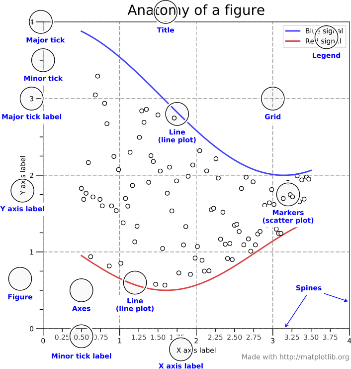

```python
Image("../images/anatomy_figure.png") # Ignore this code; it's only here to display the image below
```

# Basic plots

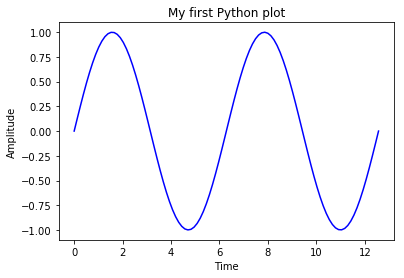

```python
import numpy as np
import matplotlib.pyplot as plt

# Generate sinusoidal data
x = np.linspace(0, 4*np.pi, 100)
y = np.sin(x)

# Plot sinusoidal curve
plt.plot(x, y, color="blue")
plt.xlabel("Time")
plt.ylabel("Amplitude")
plt.title("My first Python plot")
```

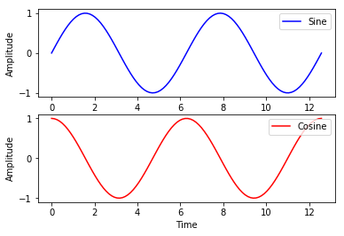

```python
plt.subplot(2, 1, 1) # 2 rows, 1 column, first plot
plt.plot(x, np.sin(x), color="b", label="Sine")
plt.ylabel("Amplitude")
plt.legend(loc="upper right")

plt.subplot(2, 1, 2) # 2 rows, 1 column, second plot
plt.plot(x, np.cos(x), color="r", label="Cosine")
plt.xlabel("Time")
plt.ylabel("Amplitude")
plt.legend(loc="upper right")
```

## Exercise 1

1. Reproduce the plots above, but change the following properties:
   - `color`
   - `linestyle`
   - `linewidth`
   - `marker`
   - `legend` location
2. Use `Numpy` to generate two random arrays `x` and `y`. Produce a scatter plot of `x` versus `y`.

**Hint 1**: Details of 2D plot properties can be found [here](https://matplotlib.org/api/lines_api.html#matplotlib.lines.Line2D)

**Hint 2**: To produce a scatter plot read `help(plt.scatter)`

# Statistical plots

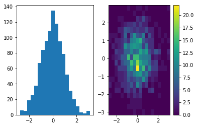

```python
# Generate 1000 normally distributed numbers
x1 = np.random.randn(1000)
x2 = np.random.randn(1000)

# 1D histogram (x1)
plt.subplot(1, 2, 1)
plt.hist(x1, bins=20)

# 2D histogram (x1 vs x2)
plt.subplot(1, 2, 2)
plt.hist2d(x1, x2, bins=20)
plt.colorbar() # display colourmap
```

[output not shown]

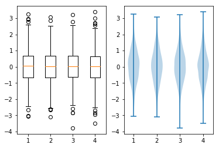

```python
# Generate four sets of random numbers
data = [np.random.randn(1000) for i in range(4)]

# Boxplot
plt.subplot(1, 2, 1)
plt.boxplot(data)

# Violin plot
plt.subplot(1, 2, 2)
plt.violinplot(data)
```

## Exercise 2

1. Reproduce the histogram plot above, but change the number of bins
2. Create a 1000 x 6 `Numpy` matrix of random numbers and produce a box and violin plot for each column of data
3. For the boxplot, change the median's colour and line width

**Hint**: Read `help(plt.boxplot)`; median properties are passed as a dictionary e.g `medianprops={"linewidth": 5}`

# 3D plots

Let us generate some artificial 3D data. In this case we will plot the exponential function

$$ z = e^{-x^2 - y^2} $$

First we need to create a grid/mesh, a 2D `Numpy` array, on which $z$ is computed on.

```python
# Generate some x, y
x = np.arange(-2.5, 2.5, 0.1)
y = np.arange(-2.5, 2.5, 0.1)
x, y = np.meshgrid(x, y) # creates a mesh/grid
x, y
```

```
(array([[-2.5, -2.4, -2.3, ...,  2.2,  2.3,  2.4],
        [-2.5, -2.4, -2.3, ...,  2.2,  2.3,  2.4],
        [-2.5, -2.4, -2.3, ...,  2.2,  2.3,  2.4],
        ...,
        [-2.5, -2.4, -2.3, ...,  2.2,  2.3,  2.4],
        [-2.5, -2.4, -2.3, ...,  2.2,  2.3,  2.4],
        [-2.5, -2.4, -2.3, ...,  2.2,  2.3,  2.4]]),
 array([[-2.5, -2.5, -2.5, ..., -2.5, -2.5, -2.5],
        [-2.4, -2.4, -2.4, ..., -2.4, -2.4, -2.4],
        [-2.3, -2.3, -2.3, ..., -2.3, -2.3, -2.3],
        ...,
        [ 2.2,  2.2,  2.2, ...,  2.2,  2.2,  2.2],
        [ 2.3,  2.3,  2.3, ...,  2.3,  2.3,  2.3],
        [ 2.4,  2.4,  2.4, ...,  2.4,  2.4,  2.4]]))
```

Now we can compute $z$ for **each** combination of $x$ and $y$. Note how through `Numpy`'s vectorisation process we do not need to loop through all elements of $x$ and all elements of $y$.

```python
# Compute function for each combination of x and y
z = np.exp(-x**2 - y**2)
z
```

```
array([[  3.72665317e-06,   6.08307642e-06,   9.73288695e-06, ...,
          1.52642052e-05,   9.73288695e-06,   6.08307642e-06],
       [  6.08307642e-06,   9.92950431e-06,   1.58871492e-05, ...,
          2.49160097e-05,   1.58871492e-05,   9.92950431e-06],
       [  9.73288695e-06,   1.58871492e-05,   2.54193465e-05, ...,
          3.98654709e-05,   2.54193465e-05,   1.58871492e-05],
       ...,
       [  1.52642052e-05,   2.49160097e-05,   3.98654709e-05, ...,
          6.25215038e-05,   3.98654709e-05,   2.49160097e-05],
       [  9.73288695e-06,   1.58871492e-05,   2.54193465e-05, ...,
          3.98654709e-05,   2.54193465e-05,   1.58871492e-05],
       [  6.08307642e-06,   9.92950431e-06,   1.58871492e-05, ...,
          2.49160097e-05,   1.58871492e-05,   9.92950431e-06]])
```

Now we have three variables ($x, y ,z$) represented as a 2D `Numpy` matrix. To plot in 3D, we first set the figure's axis to 3D then plot the data.

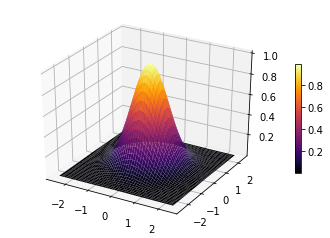

```python
from mpl_toolkits.mplot3d import Axes3D
from matplotlib import cm

# Create figure amenable for 3D plotting
hFig = plt.figure() # hFig - a handle to the figure object
hAx = hFig.gca(projection="3d") # hAx - a handle to the axis object

# Plot the surface
hSurf = hAx.plot_surface(x, y, z, cmap=cm.inferno) # hSurf - a handle to the 3D surface object
plt.colorbar(hSurf, shrink=.5)
```

# Exercise 3

1. Reproduce the above 3D plot, but pick a different colourmap from [here](https://matplotlib.org/examples/color/colormaps_reference.html)
2. Using the same simulated data produce the following plots:
   - `plot_wireframe()`
   - `scatter()`
   - `contourf()` (better displayed as a 2D plot)